# Лабораторная работа №5

Управление системными службами

Перфилов Александр Константинович | Группа НПИбд-03-24

Российский университет дружбы народов, Москва, Россия

27 сентября 2025

# Информация

## Докладчик

- Перфилов Александр Константинович
- Группа НПИбд-03-24
- Российский университет дружбы народов
- https://github.com/AlexanderPErfilovKonstantinivich?tab=repositories

# Вводная часть

## Объект и предмет исследования

- Управление системными службами

- Получить навыки управления системными службами операционной системы посред- ством systemd.

## Ход лабораторной работы

## Управление сервисами

## Заходим в root

- Заходим под уч запись root

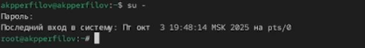

## Служба Very Secure FTP

- Проверяем статус службы Very Secure FTP

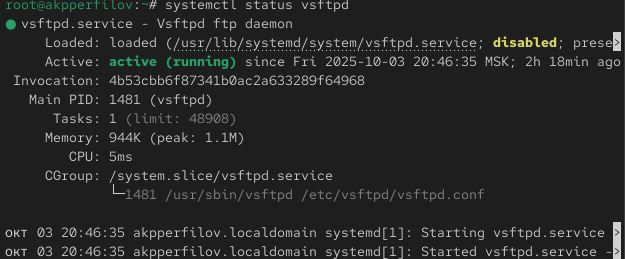

## Установка службы Very Secure FTP

- Установливаем службу Very Secure FTP

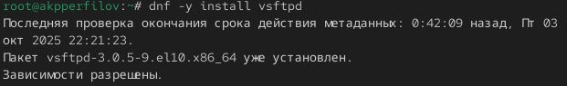

## Запуск службы Very Secure FTP

- Запускаем службу Very Secure FTP

## Проверяем статус службы Very Secure FTP

- Проверяем статус с помощью systemctl status vsftpd
- Вывод команды должен показать, что служба в настоящее время работает, но не будет активирована при перезапуске операционной системы

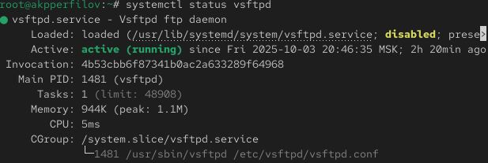

## Добавляем службу Very Secure FTP в автозапуск при загрузке операционной системы

- Используем команду systemcl enable vsftpd

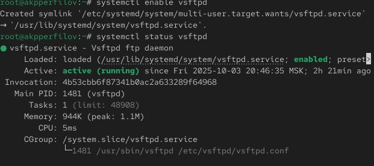

## Выведем на экран символические ссылки, ответственные за запуск различных сервисов

- Выводим с помощью команды ls /etc/systemd/system/multi-user.target.wants

[figure not shown]

## Добавляем службу Very Secure FTP в автозапуск

- Вводим команду systemctl enable vsftpd

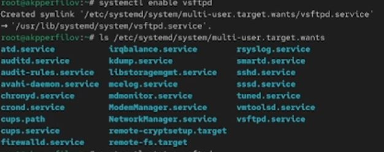

## Проверяем статус службы Very Secure FTP

- Проверяем статус службы командой systemctl status vsftpd

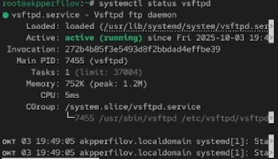

- МЫ увидим что для файла юнита состояние изменено с disabled на enabled

## Выводим на экран список зависимостей юнита

- Используем команду systemctl list-dependencies vsftpd

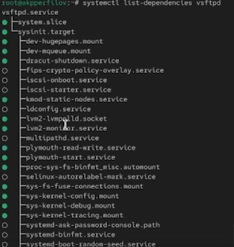

## Выводим на экран список юнитов, которые зависят от данного юнита

- Используем команду systemctl list-dependencies vsftpd –reverse

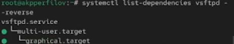

## Получаем полномочия администратора и устанавливаем iptables

- Для установки вводим dnf -y install iptables*

[figure not shown]

## Проверяем статус firewalld :

- Проверяем статус с помощью команды systemctl status firewalld

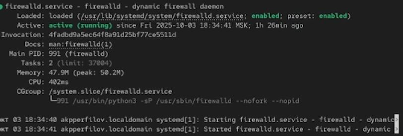

## запускаем firewalld и iptables

- Запускаем firewald с помощью systemctl start firewalld

[figure not shown]

- Запускаем iptables с помощью systemctl start iptables

## Вводим команду cat /usr/lib/systemd/system/firewalld.service

- Ищем настройки конфликтов юнита firewalld

## Вводим команду cat /usr/lib/systemd/system/iptables.service

- Ищем настройки конфликтов юнита для iptables

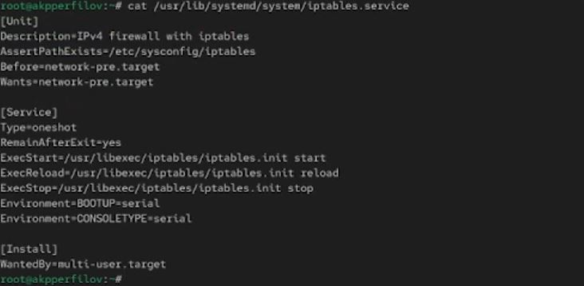

## Выгружаем службу iptables

- Для выгрузки iptables используем systemctl stop iptables

[figure not shown]

## Загружаем службу firewalld

- Загружаем службу firewald

## Блокируем запуск iptables

- Блокируем запуск введя systemctl mask iptables

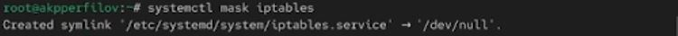

## Попробуем запустить iptables:

- Пробуем запустить iptables

## Добавляем iptables в автозапуск:

- Добавляем iptables в автозапуск

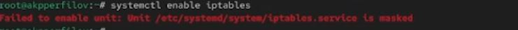

## Входим в уч запись root и преходим в каталог systemd

- Через учетную запись root переходи в каталог

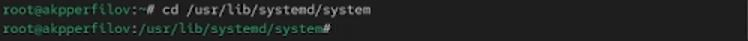

## Вводим команду grep isolate *.target

- Находим список целей которые можно изолировать

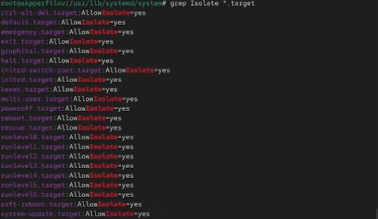

## Переключите операционную систему в режим восстановления

- Включаем режим восстановления

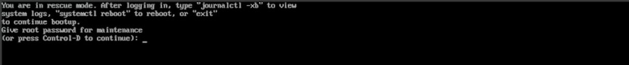

## Входим в уч запись root и вводим команду systemctl get-default

- Входим в root и вводим systemctl get-default

## Для установки цели по умолчанию используем systemctl set-default

- Устанавливаем цель с помощью systemctl set-default

## Для запуска по умолчанию текстового режима вводим systemctl setdefaultmulti-user.target

- Для запуска используеми systemctl setdefaultmulti-user.target

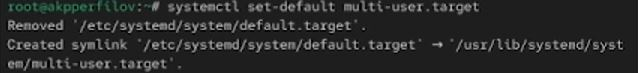

## Перезапускаем систему командой reboot

- Перезапускаем систему в графическом режиме

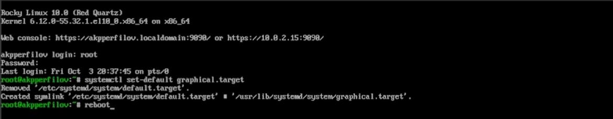

## Вывод:

В ходе работы приобретены умения по работе с управлением системными службами операционной системы посредством systemd